# Tölvuverkefni 2

Líkindareikningur og tölfræði: STÆ203G, HAG206G, MAS201F

Í þessu verkefni munið þið vinna með úrtaksdreifingu meðaltals, lögmál mikils fjölda og höfuðmarkgildisregluna sem stundum er nefnd höfuðsetning tölfræðinnar (e. central limit theorem).

Þið munið vinna með gagnasafn sem notað var við endurmat fasteignamats íbúðarhúsnæðis 2017. Þið getið lesið ykkur til um gagnasagnið hér:

https://www.skra.is/library/Samnyttar-skrar-/Fyrirtaeki-stofnanir/Fasteignamat-2017/Fasteignamat2017.pdf

Töflu yfir matssvæði er að finna á síðu 59.

Gagnaskráin sem þið eigið að vinna með má hlaða niður af Uglu, `husnaedi.csv` (úr möppunni Tölvuverkefni 2).

**Skýrslan skal að lokum sett upp í `.Rmd` skrá til að prjóna `.html` skrá (LaTeX fólk má vinna í `.Rnw` skrá og skila `.pdf` skrá). `.html` skráin verður til í sömu möppu og `.Rmd` skráin þegar þið prjónið.**

**Þið megið vinna verkefnið tvö og tvö saman en ekki í stærri hópum. Merkja þarf lausnir með nafni og HÍ-notendanafni þeirra sem unnu lausnina. Hlaða skal `.html` skrá inn á Uglu ekki síðar en 26. febrúar klukkan 23:59.**

Frágangur gildir 10% af einkunn fyrir verkefni (merkja verkefni með nafni og notendanafni, merkingar á ásum, uppsetning, merkið myndir fyrir neðan og töflur fyrir ofan, o.s.fr.)

#### a)

Lesið gagnaskrána inn og geymið í hlut sem ber upphafsstafi þeirra sem verkefnið vinna (ef Gréta Halldórsdóttir og Sigurður Jónsson eru að vinna saman skulu þau nefna hlutinn gs en ef Atli Pétursson er að vinna einn skal hann nefna hlutinn sinn ap).

```r
at <- read.csv("husnaedi.csv", header= TRUE, sep =";")
glimpse(at)
```

```
## Rows: 13,709
## Columns: 4
## $ nuvirdi    <int> 18636, 17533, 14472, 14850, 20831, 17134, 65933, 23500, ...
## $ teg_eign   <chr> "Ã\215bÃºÃ°areign", "Ã\215bÃºÃ°areign", "Ã\215bÃºÃ°areig...
## $ matssvaedi <int> 200, 70, 20, 200, 70, 220, 280, 90, 100, 72, 72, 100, 90...
## $ ibm2       <int> 117, 679, 457, 781, 874, 692, 1971, 854, 1008, 786, 1232...
```

Hver hópur á að vinna með íbúðareignir úr einu af eftirfarandi hverfum:

- Miðbær: Frá Tjörn að Snorrabraut (matssvæði 20)
- Holt/Tún (matssvæði 90)
- Laugarneshverfi/Vogar (matssvæði 100)

```r
set.seed(1608)
(hverfi<-sample(c(20,90,100),1))
```

```
## [1] 90
```

Notið svo `filter` skipunina til að velja úr þær línur úr stóru gagnatöflunni sem innihalda aðeins **íbúðareignir úr viðeigandi hverfi**. Þið skuluð yfirskrifa stóru gagnatöfluna (þ.e. notið sama nafn).

```r
at <- filter(at, at$matssvaedi== hverfi)
glimpse(at)
```

```
## Rows: 1,271
## Columns: 4
## $ nuvirdi    <int> 23500, 31468, 18438, 21636, 27834, 32265, 27924, 19484, ...
## $ teg_eign   <chr> "Ã\215bÃºÃ°areign", "Ã\215bÃºÃ°areign", "Ã\215bÃºÃ°areig...
## $ matssvaedi <int> 90, 90, 90, 90, 90, 90, 90, 90, 90, 90, 90, 90, 90, 90, ...
## $ ibm2       <int> 854, 949, 773, 848, 945, 998, 804, 594, 566, 51, 1406, 4...
```

#### b)

Teiknið stuðlarit af verði íbúðanna - munið að merkja ásana rétt.

Reiknið og tilgreinið meðalverð og dreifni verðs íbúðanna í samfelldu máli (ekki harðkóða gildin heldur látið R reikna þau út fyrir ykkur, geymið í breytum og látið knit birta gildi breytanna í samfelldum texta í skýrslunni).

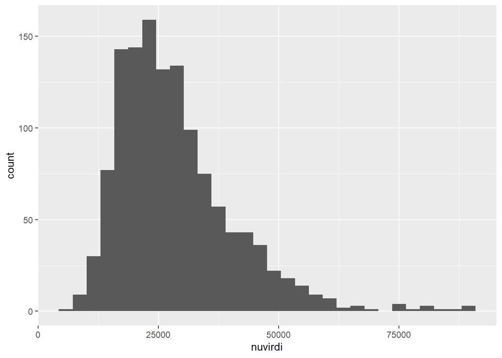

```r
b <- ggplot(at, aes(nuvirdi)) + geom_histogram()
b
```

```r
m = mean(at$nuvirdi)
s = var(at$nuvirdi)
```

```
## [1] "Meðaltal verðs á íbúðunum (reiknað með mean falli) er:"
```

```
## [1] 28510.53
```

```
## [1] "og dreifni (reiknað með var falli) er:"
```

```
## [1] 145735394
```

#### c)

Við lítum nú svo á að við höfum mælingar á öllu þýðinu, þ.e. íbúðirnar í gagnatöflunni ykkar eru þýðið og eiginleikinn sem við höfum mælt er verð þeirra, `nuvirdi`. Við þekkjum því $\mu$ og $\sigma^2$ og reiknuðum þessar stærðir í lið b).

Búið til 5000 úrtök úr þýðinu af stærðum $n = 1, 2, 3, \ldots, 5000$, þ.e. fyrsta úrtakið inniheldur einn gagnapunkt, það næsta tvo, það þriðja þrjá o.s.fr. og það síðasta 5000 gagnapunkta. Reiknið meðaltalið af hverju og einu úrtaki þ.a. þið hafið 5000 meðaltöl í vigri.

Allt þetta má gera í einni línu af kóða með því að nota föllin `sapply()` og `sample()`. Munið að hægt er að sækja dálkinn `nuvirdi` í gagnarammann `jh` með `jh$nuvirdi`.

Teiknið **línurit** af meðaltölunum, þar sem gildi meðaltalanna er á y-ás en númer úrtaks er á x-ás. Teiknið inn á línuritið beina lárétta rauða línu sem sýnir sanna meðaltal þýðisins, $\mu$ reiknað í b) lið. Þetta má gera með því að nota `qplot() + geom_hline()` föllin.

Útskýrið í samfelldu máli hvað er að gerast á myndina og tiltakið hvaða líkindafræðilega fyrirbæri myndin sýnir.

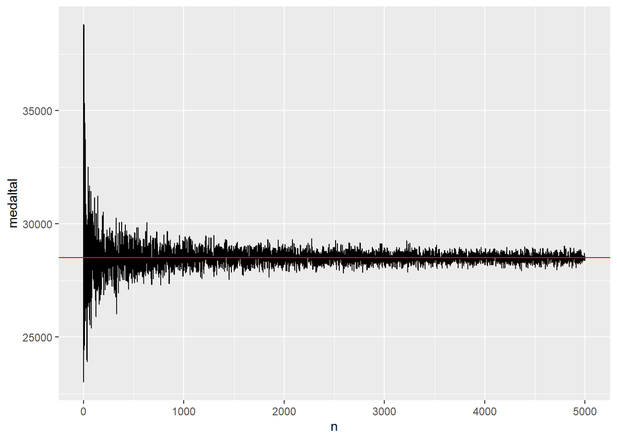

```r
n=1:5000
medaltal=sapply(n,function(x) {mean(sample(at$nuvirdi, x ,replace=TRUE))})
b <- tibble(n, medaltal) %>% ggplot(aes(x=n, y=medaltal)) + geom_line()
b + geom_hline(yintercept = m, color = "red")
```

#### d)

Takið 10000 sinnum úrtak af stærð $n = 2$ úr þýðinu, reiknið meðaltal úrtakanna og geymið í vigri sem heitir `staerd1`. Þessi vigur á að innihalda 10000 meðaltöl.

```r
staerd1 <- replicate(10000, mean(sample(at$nuvirdi, size = 2, replace = TRUE)))
staerd2 <- replicate(10000, mean(sample(at$nuvirdi, size = 5, replace = TRUE)))
staerd3 <- replicate(10000, mean(sample(at$nuvirdi, size = 20, replace = TRUE)))
staerd4 <- replicate(10000, mean(sample(at$nuvirdi, size = 40, replace = TRUE)))
```

#### e)

Í þessum lið eigið þið að teikna stuðlarit af `staerd1, staerd2, staerd3` og `staerd4`. Til þess að gera það mæli ég með að þið búið til gagnatöflu sem inniheldur vigrana fjóra, skoðið `tibble()` fallið.

Þessi gagnatafla er á svo kölluðu víðu sniði (wide format) en áður en við getum teiknað stuðlaritin þurfum við að koma henni á langt snið (long format). Það má gera á auðveldan hátt með `pivot_longer()` aðferðinni úr `tidyr` pakkanum.

Skoðið gagnatöfluna sem verður til áður en lengra er haldið og gangið úr skugga um að allt sé með felldu.

Teiknið nú stuðlarit af `staerd1, staerd2, staerd3` og `staerd4`. Teiknið sanna meðaltal þýðisins, $\mu$, inn á myndirnar með rauðri lóðréttri línu.

Auðvelt er fá stuðlaritin fjögur með því að nota `facet_wrap()` aðferðina, sjá t.d. [hér](http://docs.ggplot2.org/0.9.3.1/facet_wrap.html). Skalinn á x-ásnum á að vera sá sami (sjálfgefna stillingin í `facet_wrap()` aðferðinni).

Notið stillinguna `bins=50` í geom-fallinu.

```r
tib <- tibble(staerd1, staerd2, staerd3, staerd4)
tib2 <- tib %>% pivot_longer(cols = starts_with('s'), names_to = "Stærðir", values_to = "kr")
tib2
```

```
## # A tibble: 40,000 x 2
##    Stærðir     kr
##    <chr>    <dbl>
##  1 staerd1 26393
##  2 staerd2 25292.
##  3 staerd3 29547.
##  4 staerd4 27389.
##  5 staerd1 17654.
##  6 staerd2 22090.
##  7 staerd3 24797.
##  8 staerd4 28187.
##  9 staerd1 27402.
## 10 staerd2 23214.
## # ... with 39,990 more rows
```

Hér er allt eins og það á að vera í töflunni.

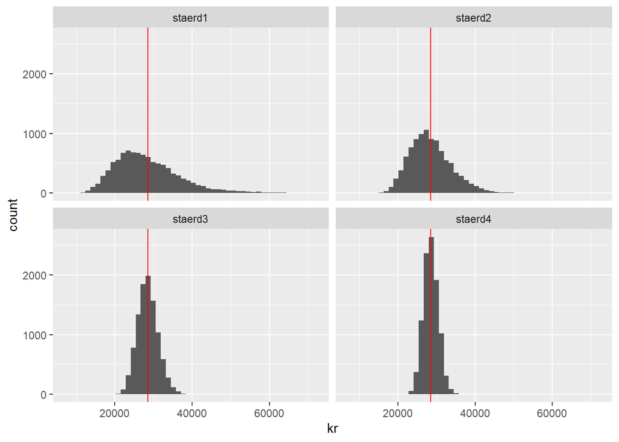

```r
e <- ggplot(tib2, aes(kr)) + geom_histogram(bins = 50)
e <- e + facet_wrap(vars(Stærðir))
e + geom_vline(xintercept = m, color = "red")
```

#### f)

Notið stillinguna `bins=50` í geom-fallinu.

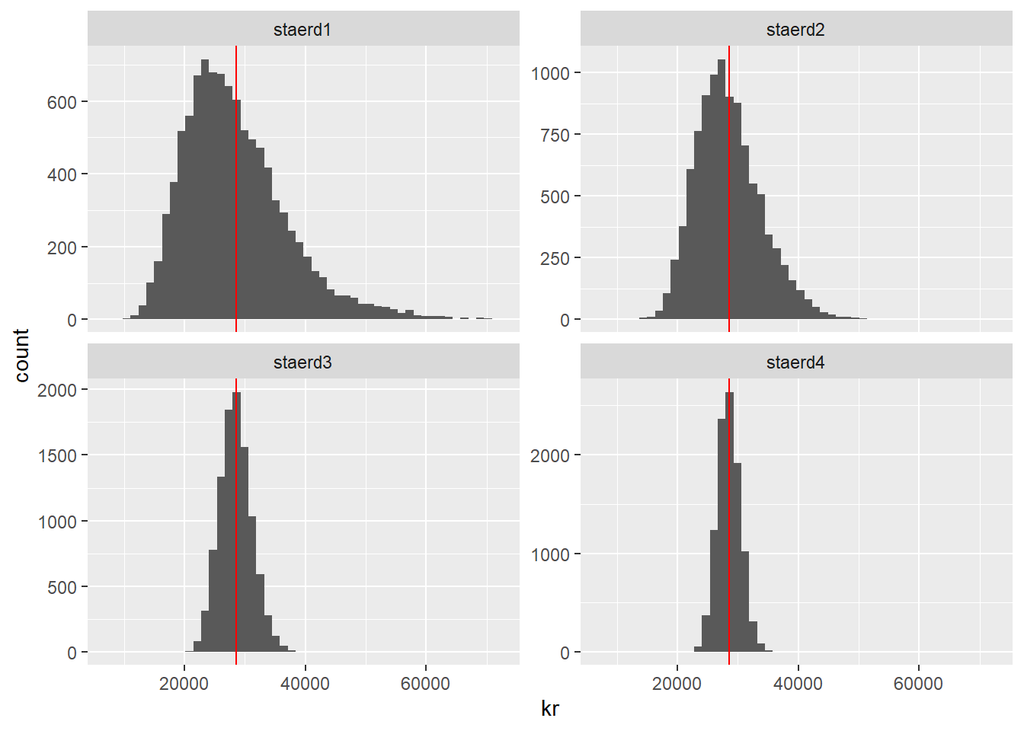

```r
f <- ggplot(tib2, aes(kr)) + geom_histogram(bins = 50)
f <- f + facet_wrap(vars(Stærðir), scales = "free_y")
f + geom_vline(xintercept = m, color = "red")
```

#### g)

```r
mean1 <- mean(staerd1)
mean2 <- mean(staerd2)
mean3 <- mean(staerd3)
mean4 <- mean(staerd4)

std1 <- var(staerd1)
std2 <- var(staerd2)
std3 <- var(staerd3)
std4 <- var(staerd4)

table <- tib2 %>% group_by(Stærðir) %>% summarise(mean = mean(kr), dreifni = var(kr),)
bind_rows(table, tibble(Stærðir="Þýði", mean=m, dreifni=s))
```

```
## # A tibble: 5 x 3
##   Stærðir   mean    dreifni
##   <chr>    <dbl>      <dbl>
## 1 staerd1 28466.  73536612.
## 2 staerd2 28454.  29408350.
## 3 staerd3 28494.   7111284.
## 4 staerd4 28511.   3628809.
## 5 Þýði    28511. 145735394.
```

#### h)

Setjið fram höfuðmarkgildisregluna, bæði forsendur og niðurstöðu.

Sjá [hér](https://rpruim.github.io/s341/S19/from-class/MathinRmd.html) hvernig setja má upp stærðfræði í RMarkdown.

**Höfuðmarkgildisreglan:**  
Látum $X_{1}$, $X_{2}$, … vera óháðar slembistærðir sem allar hafa sama dreififall með endanlegt væntigildi  
$\mu=E[X_{i}], i=1,2,...,$  
og endanlega strangt jákvæða dreifni  
$\sigma^{2}=Var[X_{i}], i=1,2,...$.  
Þá gildir fyrir öll $x \in R$ að  
$P(\frac{X_{1}+...+X_{n}-n\mu}{\sigma\sqrt{n}}\le{x})\rightarrow \Phi(x),$ $n \rightarrow \infty$

#### i)

Lýsið stuttlega með eigin orðum því sem þið sjáið á myndunum úr lið e) og f) og niðurstöðum ykkar úr lið g) og hvernig það tengist höfuðmarkgildisreglunni.